# FIFA Challenge

#### Introduction

This is notebook for Upgrad FIFA prediction challenge. we have used 4 datasets, 6 features & weighted average method to make naive predictions for round 16, quarter-finals, semi-finals & finals. visualization was done in tableau & remianing eda, data preprocessing & score calculation was done in R.

#### Importing Datasets

Data Sources:

1. https://www.kaggle.com/tadhgfitzgerald/fifa-international-soccer-mens-ranking-1993now (fifa_ranking.csv)
2. https://www.kaggle.com/ahmedelnaggar/fifa-worldcup-2018-dataset (World Cup 2018 Dataset.csv)
3. https://www.kaggle.com/martj42/international-football-results-from-1872-to-2017 (results.csv)
4. https://github.com/neaorin/PredictTheWorldCup/tree/master/input (matches.csv)

```r
library(ggplot2)
library(dplyr)
library(scales)

results <- read.csv("results.csv") #Match details of different teams
fifa_ranking <- read.csv("fifa_ranking.csv") #Yearwise fifa rankings of various teams
matches <- read.csv("matches.csv")
fifa2018 <- read.csv("World Cup 2018 Dataset.csv") #ranks & other details of teams participating in FIFA 2018
```

#### Feature Extraction

We will extract key features from above dataframes first to do some exploratoty analysis & later include complex features for analysis

```r
fifa_stats <- subset(fifa2018,select=c(Team,Current..FIFA.rank,Previous..titles,Previous..finals,Previous..semifinals))
```

#### Exploratory Analysis

Top Ten Champions competing in FIFA 2018

```r
#head(sort(fifa_stats$Current..FIFA.rank), n = 10)
x = arrange(fifa_stats,Current..FIFA.rank)
x = x[1:10,]
head(x,10)
```

Visualization: FIFA 2018 Tableau Dashboard https://public.tableau.com/profile/mohit5191#!/vizhome/FIFA2018ExploratotyAnalysis/Dashboard1

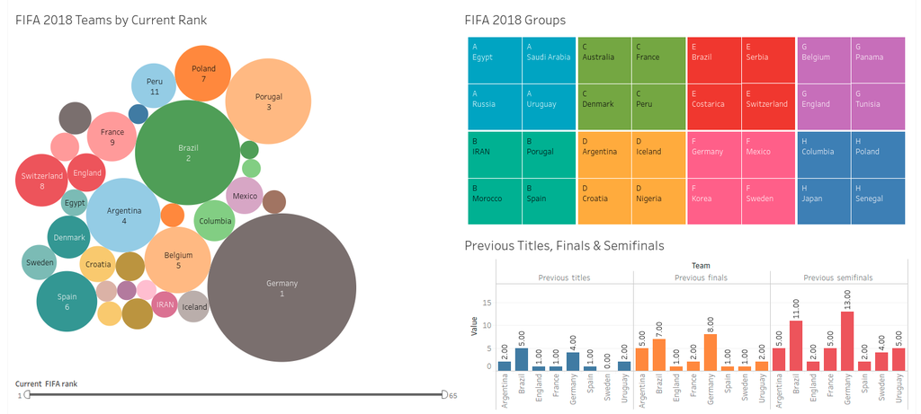

#### Lets check average ranking based on team ranking from 1993 to 2018

```r
AverageRank <- fifa_ranking %>% group_by(country_full) %>% summarise(mean(rank)) %>% setNames(c('Country', 'AverageRank')) %>% arrange(AverageRank)
AverageRank <- as.data.frame(AverageRank)
head(AverageRank,10)
```

#### Checking Average total points of teams

```r
AverageTotalPoints <- fifa_ranking %>% group_by(country_full) %>% summarise(mean(total_points)) %>% setNames(c('Country', 'AverageTotalPoints')) %>% arrange(desc(AverageTotalPoints))
AverageTotalPoints <- as.data.frame(AverageTotalPoints)
head(AverageTotalPoints,10)
```

#### Analyzing matches among various teams

```r
levels(matches$CupName)
```

```r
fifa_matches <- subset(matches,CupName="FIFA competition team final")
```

#### Finding total goals scored by different teams

```r
TotalGoalsT1 <- fifa_matches %>% group_by(team1Text) %>% summarise(sum(team1Score)) %>% setNames(c('Country', 'TotalGoals')) %>% arrange(desc(TotalGoals))

TotalGoalsT2 <- fifa_matches %>% group_by(team2Text) %>% summarise(sum(team2Score)) %>% setNames(c('Country', 'TotalGoals')) %>% arrange(desc(TotalGoals))
```

#### Finding lead maintained by various teams during past FIFA teams

```r
fifa_matches$team1Lead <- fifa_matches$team1Score - fifa_matches$team2Score
fifa_matches$team2Lead <- fifa_matches$team2Score - fifa_matches$team1Score

fifa_matches_team1 <- subset(fifa_matches,select=c(team1Text,team1Lead))
fifa_matches_team2 <- subset(fifa_matches,select=c(team2Text,team2Lead))

fifa_matches_team1_avg <- fifa_matches_team1 %>% group_by(team1Text) %>% summarise(mean(team1Lead, na.rm = TRUE)) %>% setNames(c('Country', 'AverageLead')) %>% arrange(desc(AverageLead))

fifa_matches_team2_avg <- fifa_matches_team2 %>% group_by(team2Text) %>% summarise(mean(team2Lead, na.rm = TRUE)) %>% setNames(c('Country', 'AverageLead'))

fifa_matches_teams_avg <- merge(fifa_matches_team1_avg, fifa_matches_team2_avg, by = "Country")
fifa_matches_teams_avg$AverageLead <- fifa_matches_teams_avg$AverageLead.x + fifa_matches_teams_avg$AverageLead.y
fifa_matches_teams_avg <- subset(fifa_matches_teams_avg,select=c(Country,AverageLead))
```

#### Lets combine these features & analyse further

```r
fifa <- data_frame()

fifa <- merge(fifa_stats,AverageRank,by.x = "Team",by.y = "Country")
fifa <- merge(fifa,AverageTotalPoints,by.x = "Team",by.y = "Country")

fifa <- merge(fifa,fifa_matches_teams_avg,by.x = "Team",by.y = "Country")
```

*So final selected features for prediction are Previous Titles, Previous Finals, Previous Semifinals, Average Total Points, Average Lead & Average Rank. however these features need further prerocessing.*

#### Further Preprocessing

```r
fifa <- fifa[,-c(2)]
fifa$InverseAvgRank <- 1/fifa$AverageRank
fifa <- fifa[,-c(5)]
```

#### Scaling Data

This step is neccessary as we will be using a weighted average for predictions, here we are scaling all 6 features on scle of 1 to 10

```r
fifa_subset <- fifa[,c(2:7)]
fifa_subset <- data.frame(lapply(fifa_subset,function(x) rescale(as.numeric(x), to=c(1,10))))

summary(fifa_subset)
```

#### Calculating weighted winning likelihood

Weightages given to features are:

| Feature | Weightage |
| --- | --- |
| Previous Titles | 5% |
| Previous Finals | 10% |
| Previous Semifinals | 10% |
| Average Total Points | 25% |
| Average Lead | 25% |
| Average Rank | 25% |

```r
fifa <- cbind(fifa[,c(1)],fifa_subset)
names(fifa)[names(fifa) == "fifa[, c(1)]"] <- "Team"

WinningWeightage = c()
for(i in 1:nrow(fifa)){
WinningScore <- sum(fifa[i,2]*.05,fifa[i,3]*.1,fifa[i,4]*.1,fifa[i,5]*.25,fifa[i,6]*.25,fifa[i,7]*.25)
WinningWeightage <- c(WinningWeightage, WinningScore)
}

fifa$WinChance <- WinningWeightage
```

#### Calculating individual match winners using WinChance, predicted winners are mentioned in comment after each comparision

#### Current Team Positions

[figure not shown]

#### Round 16:

```r
which(fifa[fifa$Team=="France",]$WinChance > fifa[fifa$Team=="Argentina",]$WinChance) #Argentina
#which(fifa[fifa$Team=="Uruguay",]$WinChance > fifa[fifa$Team=="Porugal",]$WinChance) Porugal

which(fifa[fifa$Team=="Brazil",]$WinChance > fifa[fifa$Team=="Mexico",]$WinChance) #Brazil
which(fifa[fifa$Team=="Belgium",]$WinChance > fifa[fifa$Team=="Japan",]$WinChance) #Belgium

which(fifa[fifa$Team=="Spain",]$WinChance > fifa[fifa$Team=="Russia",]$WinChance) #Spain
which(fifa[fifa$Team=="Croatia",]$WinChance > fifa[fifa$Team=="Denmark",]$WinChance) #Croatia

which(fifa[fifa$Team=="Sweden",]$WinChance > fifa[fifa$Team=="Switzerland",]$WinChance) #Sweden
#which(fifa[fifa$Team=="Columbia",]$WinChance > fifa[fifa$Team=="England",]$WinChance) #England
```

#### Quarter-Finals:

```r
which(fifa[fifa$Team=="Porugal",]$WinChance > fifa[fifa$Team=="Argentina",]$WinChance) #Argentina
which(fifa[fifa$Team=="Brazil",]$WinChance > fifa[fifa$Team=="Belgium",]$WinChance) #Brazil

which(fifa[fifa$Team=="Spain",]$WinChance > fifa[fifa$Team=="Croatia",]$WinChance) #Spain
which(fifa[fifa$Team=="Sweden",]$WinChance > fifa[fifa$Team=="England",]$WinChance) #England
```

#### Semi-Finals:

```r
which(fifa[fifa$Team=="Brazil",]$WinChance > fifa[fifa$Team=="Argentina",]$WinChance) #Brazil
which(fifa[fifa$Team=="Spain",]$WinChance > fifa[fifa$Team=="England",]$WinChance) #Spain
```

#### Finals:

```r
which(fifa[fifa$Team=="Spain",]$WinChance > fifa[fifa$Team=="Brazil",]$WinChance) #Brazil
```

So Brzail should win FIFA 2018 as per our naive approach.

```r
#write.csv(fifa,"final_dataset.csv")
```